# Imputation of Survival Data

## Preface

### R packages

In this practical, a number of R packages are used. If any of them are not installed you may be able to follow the practical but will not be able to run all of the code. The packages used (with versions that were used to generate the solutions) are:

- R version 4.0.0 (2020-04-24)
- `mice` (version: 3.8.0)
- `survival` (version: 3.1.12
- `JointAI` (version: 0.6.1)
- `ggplot2` (version: 3.3.0)

### Help files

You can find help files for any function by adding a `?` before the name of the function.

Alternatively, you can look up the help pages online at https://www.rdocumentation.org/ or find the whole manual for a package at https://cran.r-project.org/web/packages/available_packages_by_name.html

### Data & Model of interest

For this practical, we will use the **EP16dat3** dataset, which is a subset of the PBC (Primary Biliary Cirrhosis) data.

To get the **EP16dat3** dataset, load the file `EP16dat3.RData`. You can download it [here](https://nerler.github.io/EP16_Multiple_Imputation/practical/data/index.html).

To load this dataset into R, you can use the command `file.choose()` which opens the explorer and allows you to navigate to the location of the file on your computer.

If you know the path to the file, you can also use `load("<path>/EP16dat3.RData")`.

The variables contained in this subset (`EP16dat3`) are:

| time | number of years between inclusion and death, transplantion, or end of follow-up |
| --- | --- |
| status | status at `time` (censored, transplant, dead) |
| age | patient’s age at intake |
| sex | patient’s sex |
| platelet | platelet count |
| chol | serum cholesterol |
| stage | histologic stage of disease |

The variables in `EP16dat3` dataset have the following distributions:

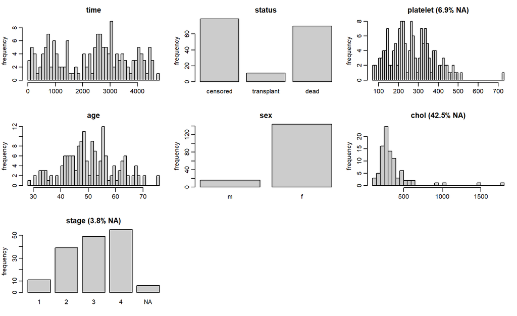

The missing data pattern is

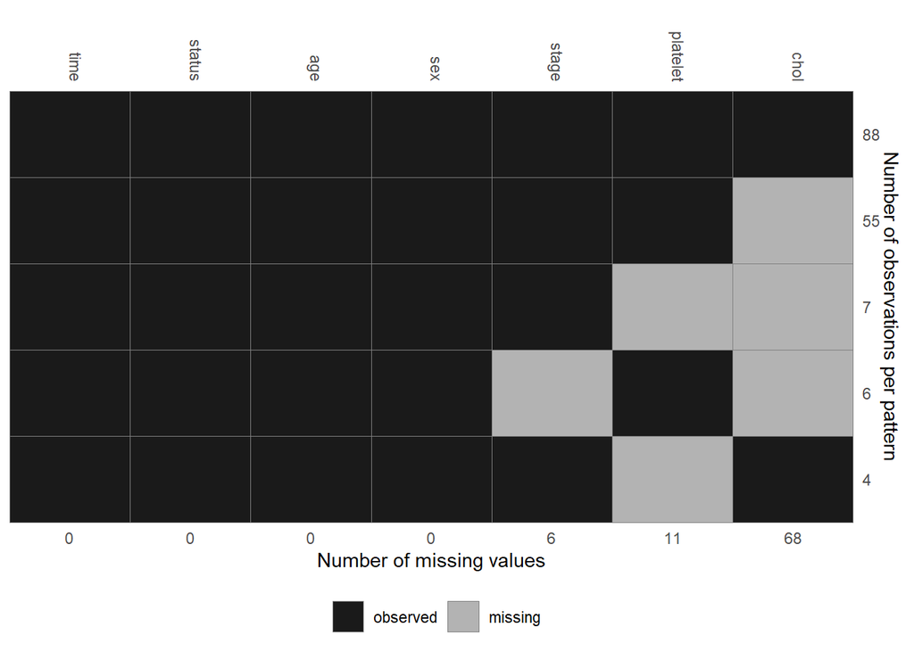

We are interested to determine predictor variables for patient survival, using the following Cox proportional hazards model:

```r
coxph(Surv(time, status %in% c('transplant', 'dead') ~ platelet + age + sex + chol + stage)
```

## Imputation with **mice**

As we have seen in the lecture, the **mice** package provides the function `nelsonaalen()` that calculates the Nelson-Aalen estimator with which the cumulative Hazard can be approximated.

### Task 1

- Calculate the Nelson-Aalen estimate for patient survival in the EP16dat3 data and
- perform the usual setup steps for imputation using `mice()`.

Note:

`nelsonaalen()` does not accept the `%in% c('transplant', 'dead')` specification of the event, hence, we need to create a new event indicator `event`.

### Solution 1

We first creat the event variable, and calculate the Nelson-Aalen estimator:

```r
library("mice")
library("survival")

EP16dat3$event <- EP16dat3$status %in% c('transplant', 'dead')
EP16dat3$na <- nelsonaalen(data = EP16dat3, timevar = "time",  statusvar = "event")
```

Then we can continue as usual, by doing the set-up run and adpating the arguments `method` and `predictorMatrix`:

```r
micesurv0 <- mice(EP16dat3, maxit = 0)
micesurvmeth <- micesurv0$meth
micesurvpred <- micesurv0$pred
```

We can set the imputation for `platelet` to `"norm"`, since this variable has a relatively symmetric distribution, and exclude `time` as predictor from the imputation models:

```r
micesurvmeth[c("platelet")] <- "norm"
micesurvpred[, "time"] <- 0
```

We can now check our settings:

```r
# check the method and predictorMatrix
micesurvmeth
```

```
##     time   status platelet      age      sex     chol    stage    event       na
##       ""       ""   "norm"       ""       ""    "pmm"   "polr"       ""       ""
```

```r
micesurvpred
```

```
##          time status platelet age sex chol stage event na
## time        0      1        1   1   1    1     1     1  1
## status      0      0        1   1   1    1     1     1  1
## platelet    0      1        0   1   1    1     1     1  1
## age         0      1        1   0   1    1     1     1  1
## sex         0      1        1   1   0    1     1     1  1
## chol        0      1        1   1   1    0     1     1  1
## stage       0      1        1   1   1    1     0     1  1
## event       0      1        1   1   1    1     1     0  1
## na          0      1        1   1   1    1     1     1  0
```

### Task 2

Run the imputation and analyse the imputed data.

### Solution 2

Run the imputation:

```r
micesurv <- mice(EP16dat3, predictorMatrix = micesurvpred, maxit = 10, m = 5,
                 printFlag = FALSE, seed = 2020)
```

Fit the model and pool the results:

```r
micesurv_mira <- with(micesurv, coxph(Surv(time = time, event) ~ platelet +
                                        age + sex + chol + stage))

summary(pool(micesurv_mira), conf.int = TRUE)
```

```
## Warning: Unknown or uninitialised column: `df.residual`.
```

```
## Warning in pool.fitlist(getfit(object), dfcom = dfcom): Large sample assumed.
```

```
##       term   estimate  std.error statistic       df  p.value      2.5 %      97.5 %
## 1 platelet -0.0029485 0.00134143  -2.19803 2923.600 0.028025 -0.0055788 -0.00031826
## 2      age  0.0325684 0.01337407   2.43519 1199.343 0.015029  0.0063292  0.05880754
## 3     sexf -0.0593014 0.36715887  -0.16151 7940.218 0.871692 -0.7790293  0.66042642
## 4     chol  0.0017741 0.00063863   2.77796   15.541 0.013717  0.0004170  0.00313118
## 5  stage.L  1.3898638 0.65834507   2.11115  330.368 0.035510  0.0947867  2.68494087
## 6  stage.Q  0.2155697 0.54448484   0.39592  203.070 0.692583 -0.8579990  1.28913853
## 7  stage.C  0.3957197 0.33539469   1.17986 5284.986 0.238108 -0.2617923  1.05323182
```

Note:

When we do the pooling, we get two warning messages.

The function `pool()` has an argument `dfcom`, refering to the degrees of freedom from the complete data analysis, which is `NULL` by default. In that case, mice will try to extract them from the first analysis. But this fails for a Cox PH model.

The first warning message (about the unknown column `df.residual`) can just be ignored.

The second warning means that, because the degrees of freedom could not be extracted from the model, it will be assumed that this number is very large (i.e., that the data is really large compared to the number of parameters that are estimated).

You can prevent these warning messages by specifying the argument `dfcom` in the function `pool()`.

### About Contrasts

In the summary of the pooled results we see that orthogonal polynomial coding for the ordered factor `stage` was used. Hence, we cannot interpret the coefficients from this variable the way we would interpret dummy variables.

For some model types we can overwrite the default contrasts (i.e., how categorical variables are handled) using an argument `contrasts`. In a linear or logistic regression model, for example we could specify `contrasts = list(stage = 'contr.treatment')`.

Unfortunately, this is not possible for `coxph()`. Here we need to change the global option how contrasts can be set.

The global option for contrasts looks like this:

```r
options("contrasts")
```

```
## $contrasts
##         unordered           ordered
## "contr.treatment"      "contr.poly"
```

`contr.treatment` refers to dummy coding and `contr.poly` to orthogonal polynomials. We would like to also use `contr.treatment` for ordered factors.

To be able to change the setting back, we first save the current options:

```r
op <- options()
```

Then we can overwrite the options for the contrasts:

```r
options(contrasts = rep('contr.treatment', 2))
options("contrasts")
```

```
## $contrasts
## [1] "contr.treatment" "contr.treatment"
```

```r
micesurv_mira2 <- with(micesurv, coxph(Surv(time = time, event) ~ platelet +
                                        age + sex + chol + stage))

summary(pool(micesurv_mira), conf.int = TRUE)
```

```
##       term   estimate  std.error statistic       df  p.value      2.5 %      97.5 %
## 1 platelet -0.0029485 0.00134143  -2.19803 2923.600 0.028025 -0.0055788 -0.00031826
## 2      age  0.0325684 0.01337407   2.43519 1199.343 0.015029  0.0063292  0.05880754
## 3     sexf -0.0593014 0.36715887  -0.16151 7940.218 0.871692 -0.7790293  0.66042642
## 4     chol  0.0017741 0.00063863   2.77796   15.541 0.013717  0.0004170  0.00313118
## 5  stage.L  1.3898638 0.65834507   2.11115  330.368 0.035510  0.0947867  2.68494087
## 6  stage.Q  0.2155697 0.54448484   0.39592  203.070 0.692583 -0.8579990  1.28913853
## 7  stage.C  0.3957197 0.33539469   1.17986 5284.986 0.238108 -0.2617923  1.05323182
```

Afterwards, we change the settings back:

```r
options(op)
options("contrasts")
```

```
## $contrasts
##         unordered           ordered
## "contr.treatment"      "contr.poly"
```

## Imputation with **JointAI**

Analysis of a Cox proportional hazards model using **JointAI** works analogous to the function `coxph()` from packages survival.

### Solution 1

```r
library("JointAI")
JointAIcox <- coxph_imp(Surv(time = time, event) ~ platelet + age + sex + chol + stage,
                        data = EP16dat3, n.iter = 1500, seed = 2020)
```

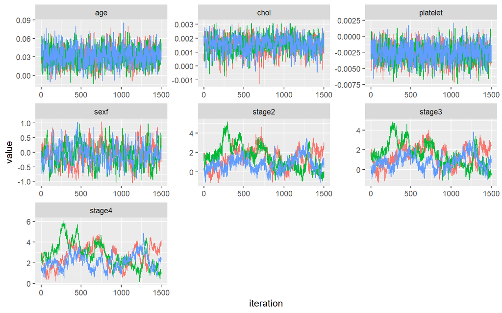

```r
traceplot(JointAIcox, use_ggplot = TRUE) +
  theme(legend.position = 'none')
```

The mixing of the parameters for `stage` is not great. We would have to increase the number of iterations and/or the number of chains to get better results.

### Task 2

When the groups of a categorical variable are unbalanced, convergence is usually better when the largest group (or a relatively large group) is used as the reference category.

```r
JointAIcox2 <- coxph_imp(Surv(time = time, event) ~ platelet + age + sex + chol + stage,
                         data = EP16dat3, n.iter = 500, seed = 2020,
                         refcats = list(stage = 4))
```

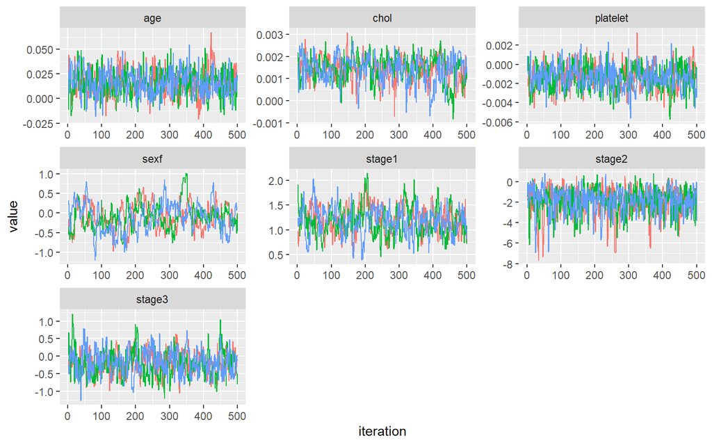

```r
traceplot(JointAIcox2, use_ggplot = TRUE) +
  theme(legend.position = 'none')
```

## Additional excercise JointAI

For larger datasets with many different event times the Cox model implemented in **JointAI** can become quite slow. This is because it has to use the counting process notation which requires a loop over all event times in each iteration of the MCMC sampler.

A parametric survival model, e.g. assuming a Weibull distribution (see Section 4.2 of the [slides of EP03: Biostatistical Methods II: Survival Analysis](http://www.drizopoulos.com/courses/EMC/EP03.pdf)), is often faster. This is implemented in the function `survreg_imp()`.

### Task 1

- Fit a Weibull survival model using the model structure of the Cox model.
- Investigate convergence using the `traceplot()` and the Gelman-Rubin criterion (`GR_crit()`).

### Solution 1

```r
JointAIsurv <- survreg_imp(Surv(time = time, event) ~ platelet +
                             age + sex + chol + stage, data = EP16dat3,
                           n.iter = 1500, seed = 2020)
```

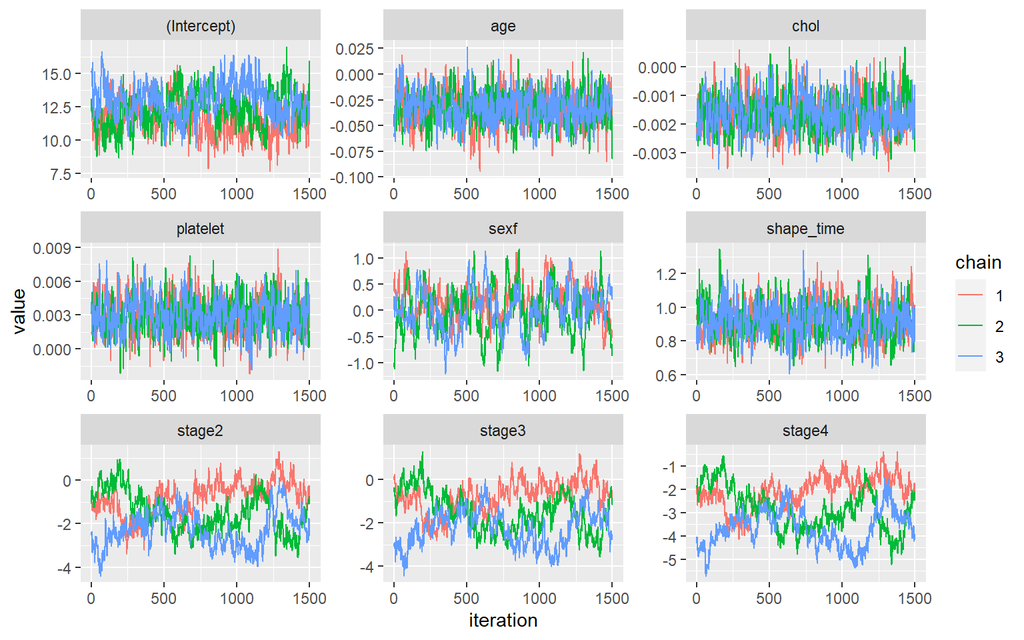

```r
traceplot(JointAIsurv, use_ggplot = TRUE)
```

```r
GR_crit(JointAIsurv, autoburnin = FALSE)
```

```
## Potential scale reduction factors:
##
##             Point est. Upper C.I.
## (Intercept)       1.29       1.80
## platelet          1.00       1.01
## age               1.00       1.01
## sexf              1.06       1.20
## chol              1.00       1.00
## stage2            1.57       2.42
## stage3            1.60       2.50
## stage4            1.67       2.67
## shape_time        1.00       1.02
##
## Multivariate psrf
##
## 1.47
```

Both the traceplot and the Gelman-Rubin criterion show that the parameters for `stage` don’t converge well. There are clear patterns visible in the plots and the upper limit of the confidence intverval of the Gelman-Rubin criterion is much larger than one.

### Task 2

In some cases, convergence of coefficients for categorical variables can be improved by changing the reference category. Especially when the categories are very unbalanced, convergence it better when the largest (or a large) category is chosen as the reference.

The plot of the distribution of the variables in the `EP16dat3` data at the beginning of this practical shows that there are few patients with stage 1.

- Re-run the Weibull survival model with the most frequent category of `stage` as reference (using the argument `refcats`).

Check out the [help file](https://nerler.github.io/JointAI/reference/model_imp.html) and the vignette on [Model Specification](https://nerler.github.io/JointAI/articles/ModelSpecification.html#reference-values-for-categorical-covariates) for more details on how to use the argument `refcats`.

- Then look at the `traceplot()` and `GR_crit()` to see if the change in reference category improved convergence.

### Solution 2

```r
JointAIsurv2 <- survreg_imp(Surv(time = time, event) ~ platelet +
                              age + sex + chol + stage, data = EP16dat3,
                            n.iter = 1000, seed = 2020, refcats = 'largest')
```

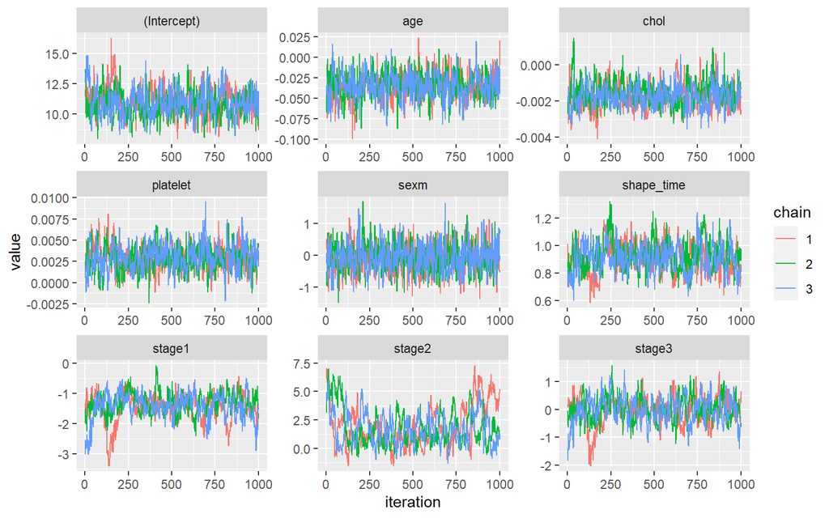

```r
traceplot(JointAIsurv2, use_ggplot = TRUE)
```

```r
GR_crit(JointAIsurv2, autoburnin = FALSE)
```

```
## Potential scale reduction factors:
##
##             Point est. Upper C.I.
## (Intercept)       1.02       1.07
## platelet          1.00       1.01
## age               1.00       1.01
## sexm              1.00       1.01
## chol              1.05       1.16
## stage1            1.03       1.10
## stage2            1.02       1.04
## stage3            1.01       1.04
## shape_time        1.01       1.04
##
## Multivariate psrf
##
## 1.06
```

The traceplots look a lot better and the Gelman-Rubin criterion has improved. Nevertheless, more iterations or chaines would be necessary to obtain more reliable results.

```r
summary(JointAIsurv2, start = 250)
```

```
##
##  Weibull survival model fitted with JointAI
##
## Call:
## survreg_imp(formula = Surv(time = time, event) ~ platelet + age +
##     sex + chol + stage, data = EP16dat3, n.iter = 1000, refcats = "largest",
##     seed = 2020)
##
## Posterior summary:
##                 Mean       SD      2.5%     97.5% tail-prob. GR-crit
## (Intercept) 10.93456 1.073726  8.879130 13.180801     0.0000    1.07
## platelet     0.00285 0.001446  0.000191  0.005810     0.0345    1.05
## age         -0.03450 0.015404 -0.066417 -0.005304     0.0274    1.01
## sexm        -0.06589 0.426925 -0.849434  0.826743     0.8641    1.01
## chol        -0.00168 0.000654 -0.002851 -0.000272     0.0259    1.13
## stage1      -1.37774 0.370225 -2.214133 -0.721323     0.0000    1.12
## stage2       1.69909 1.437517 -0.512874  5.070581     0.1700    1.15
## stage3       0.00196 0.434067 -0.862068  0.895789     0.9933    1.04
##
## Posterior summary of the shape of the Weibull distribution:
##        Mean    SD  2.5% 97.5% GR-crit
## shape 0.917 0.106 0.719  1.14    1.05
##
##
## MCMC settings:
## Iterations = 250:1100
## Sample size per chain = 851
## Thinning interval = 1
## Number of chains = 3
##
## Number of observations: 160
```

© Nicole Erler